# FIGURE_5_DBRDA

Published

March 30, 2026

Factors associated with microbiome, Adonis

DBRDA

It gives some measure of constrained versus unconstrained variance in the microbiome. That is to say the compositional variance that can be explained by the variables (such as termness, antibiotics, sex, etc.) that you have and the unconstrained, defined as that variance that is unable to be explained by the variables you have included in the model.

The plot you have shown is a biplot that gives some indication of direction of explained variance by each factor and this package lets you do this very well.

# Import

```r
df_species <- read.delim("baby_species.tsv")
names(df_species)[1] <- "Sample"
library(readxl)
df_clinic <- read_excel("df_clinic_final.xlsx")
df_clinic <- as.data.frame(df_clinic)
```

```r
df_species <- df_species[df_species$Sample %in% df_clinic$Sample, ]
```

```r
row.names(df_species) <- df_species$Sample

df_species <- df_species[ , -1]

df_species <- df_species + 0.001
```

```r
row.names(df_clinic) <- df_clinic$Sample
```

```r
df_species <- df_species[row.names(df_clinic), ]
```

# Compare

```r
library(compareGroups)

df_clinic$Termness <- factor(df_clinic$Termness)

table_compare <- createTable(compareGroups(Termness ~ .,
                                        data = df_clinic[ , c("Termness",
                                                              "Sex",
                                                              "Delivery_mode",
                                                              "Feeding_method",
                                                              "Probiotics",
                                                              "Antibiotics",
                                                              "Ethnicity")],
                                        ref = 1,
                                        riskratio = FALSE,
                                        byrow = TRUE),
                          show.ratio = TRUE,
                          show.p.ratio = FALSE,
                          show.p.overall = TRUE)
table_compare
```

```
--------Summary descriptives table by 'Termness'---------

__________________________________________________________________
                   preterm      term           OR        p.overall
                     N=43       N=37
¯¯¯¯¯¯¯¯¯¯¯¯¯¯¯¯¯¯¯¯¯¯¯¯¯¯¯¯¯¯¯¯¯¯¯¯¯¯¯¯¯¯¯¯¯¯¯¯¯¯¯¯¯¯¯¯¯¯¯¯¯¯¯¯¯¯
Sex:                                                       0.255
    Female        19 (46.3%) 22 (53.7%)       Ref.
    Male          24 (61.5%) 15 (38.5%) 0.55 [0.22;1.33]
Delivery_mode:                                             0.003
    C-section     38 (64.4%) 21 (35.6%)       Ref.
    Vaginal       5 (23.8%)  16 (76.2%) 5.56 [1.86;19.5]
Feeding_method:                                            0.629
    Breastfed     21 (50.0%) 21 (50.0%)       Ref.
    Non-breastfed 22 (57.9%) 16 (42.1%) 0.73 [0.30;1.78]
Probiotics:                                               <0.001
    No            6 (14.3%)  36 (85.7%)       Ref.
    Yes           37 (97.4%) 1 (2.63%)  0.01 [0.00;0.03]
Antibiotics:                                              <0.001
    No            18 (33.3%) 36 (66.7%)       Ref.
    Yes           25 (96.2%) 1 (3.85%)  0.02 [0.00;0.13]
Ethnicity:                                                 0.008
    European      14 (36.8%) 24 (63.2%)       Ref.
    non-European  29 (69.0%) 13 (31.0%) 0.27 [0.10;0.67]
¯¯¯¯¯¯¯¯¯¯¯¯¯¯¯¯¯¯¯¯¯¯¯¯¯¯¯¯¯¯¯¯¯¯¯¯¯¯¯¯¯¯¯¯¯¯¯¯¯¯¯¯¯¯¯¯¯¯¯¯¯¯¯¯¯¯
```

```r
table(Feeding_method = df_clinic$Feeding_method,
      Delivery_mode = df_clinic$Delivery_mode)
```

```
               Delivery_mode
Feeding_method  C-section Vaginal
  Breastfed            32      10
  Non-breastfed        27      11
```

```r
table(Probiotics = df_clinic$Probiotics,
      Antibiotics = df_clinic$Antibiotics)
```

```
          Antibiotics
Probiotics No Yes
       No  42   0
       Yes 12  26
```

```r
table(Probiotics = df_clinic$Probiotics,
      Ethnicity = df_clinic$Ethnicity)
```

```
          Ethnicity
Probiotics European non-European
       No        27           15
       Yes       11           27
```

```r
table(Sex = df_clinic$Sex,
      Termness = df_clinic$Termness)
```

```
        Termness
Sex      preterm term
  Female      19   22
  Male        24   15
```

# CONVERT NUMERIC

```r
df_clinic$Termness <- factor(df_clinic$Termness,
                             levels = c("term", "preterm"))

df_clinic$Termness <- as.numeric(df_clinic$Termness) - 1
```

```r
df_clinic$Sex <- factor(df_clinic$Sex,
                             levels = c("Male", "Female"))

df_clinic$Sex <- as.numeric(df_clinic$Sex) - 1
```

```r
df_clinic$Delivery_mode <- factor(df_clinic$Delivery_mode,
                             levels = c("Vaginal", "C-section"))

df_clinic$Delivery_mode <- as.numeric(df_clinic$Delivery_mode) - 1
```

```r
df_clinic$Feeding_method <- factor(df_clinic$Feeding_method,
                             levels = c("Non-breastfed", "Breastfed"))

df_clinic$Feeding_method <- as.numeric(df_clinic$Feeding_method) - 1
```

```r
df_clinic$Probiotics <- factor(df_clinic$Probiotics,
                             levels = c("No", "Yes"))

df_clinic$Probiotics <- as.numeric(df_clinic$Probiotics) - 1
```

```r
df_clinic$Antibiotics <- factor(df_clinic$Antibiotics,
                             levels = c("No", "Yes"))

df_clinic$Antibiotics <- as.numeric(df_clinic$Antibiotics) - 1
```

```r
df_clinic$Ethnicity <- factor(df_clinic$Ethnicity,
                             levels = c("non-European", "European"))

df_clinic$Ethnicity <- as.numeric(df_clinic$Ethnicity) - 1
```

# PLOT

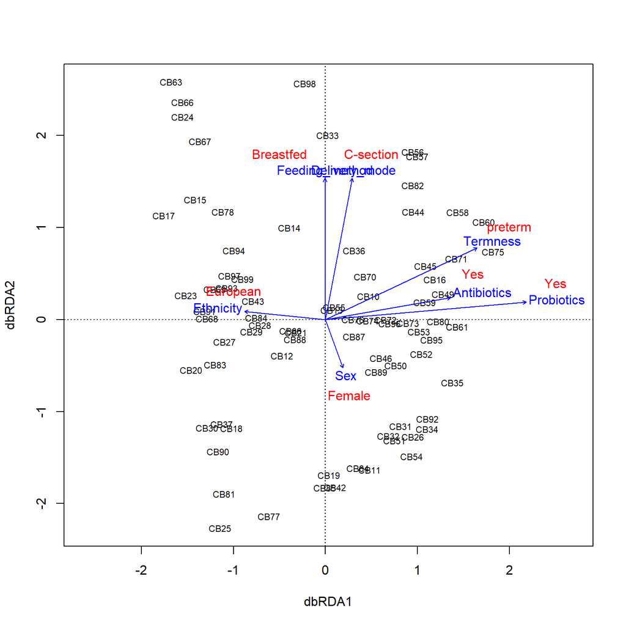

```r
library(vegan)

# The RHS can have a special term Condition that defines variables to be “partialled out” before constraints

## avoid negative eigenvalues with sqrt distances
dbrda_1 <- vegan:::dbrda(df_species ~ Termness + Sex + Delivery_mode + Probiotics + Antibiotics + Feeding_method + Ethnicity,
            data = df_clinic,
            dist="bray")

vegan:::plot.cca(dbrda_1,
                 choices = c(1, 2),
                 correlation = T,
                 arrows = F,
                 display = c(
                  "sp",
                  "wa",
                  "cn" # centroids of factor constraints
                  # "all"
                    ))

# locator(n = 1) -> ok

text(x = 0.2575,
     y = -0.8198,
     labels = "Female",
     col = "red")

text(x = 2,
     y = 1,
     labels = "preterm",
     col = "red")

text(x = 0.5,
     y = 1.8,
     labels = "C-section",
     col = "red")

text(x = -0.5,
     y = 1.8,
     labels = "Breastfed",
     col = "red")

text(x = -1,
     y = 0.3,
     labels = "European",
     col = "red")

text(x = 1.6,
     y = 0.5,
     labels = "Yes",
     col = "red")

text(x = 2.5,
     y = 0.4,
     labels = "Yes",
     col = "red")
```

```r
anova(dbrda_1)
```

```
Permutation test for dbrda under reduced model
Permutation: free
Number of permutations: 999

Model: vegan:::dbrda(formula = df_species ~ Termness + Sex + Delivery_mode + Probiotics + Antibiotics + Feeding_method + Ethnicity, data = df_clinic, distance = "bray")
         Df SumOfSqs      F Pr(>F)
Model     7   5.3534 2.0979  0.001 ***
Residual 72  26.2474
---
Signif. codes:  0 '***' 0.001 '**' 0.01 '*' 0.05 '.' 0.1 ' ' 1
```

```r
anova(dbrda_1,
      by="terms",
      permu=200)
```

```
Permutation test for dbrda under reduced model
Terms added sequentially (first to last)
Permutation: free
Number of permutations: 999

Model: vegan:::dbrda(formula = df_species ~ Termness + Sex + Delivery_mode + Probiotics + Antibiotics + Feeding_method + Ethnicity, data = df_clinic, distance = "bray")
               Df SumOfSqs      F Pr(>F)
Termness        1   1.2585 3.4522  0.001 ***
Sex             1   0.4044 1.1093  0.315
Delivery_mode   1   0.7288 1.9991  0.018 *
Probiotics      1   1.1173 3.0650  0.001 ***
Antibiotics     1   0.6958 1.9087  0.023 *
Feeding_method  1   0.6967 1.9112  0.028 *
Ethnicity       1   0.4519 1.2396  0.208
Residual       72  26.2474
---
Signif. codes:  0 '***' 0.001 '**' 0.01 '*' 0.05 '.' 0.1 ' ' 1
```

```r
summary(dbrda_1)
```

```
Call:
vegan:::dbrda(formula = df_species ~ Termness + Sex + Delivery_mode +      Probiotics + Antibiotics + Feeding_method + Ethnicity, data = df_clinic,      distance = "bray")

Partitioning of squared Bray distance:
              Inertia Proportion
Total          31.601     1.0000
Constrained     5.353     0.1694
Unconstrained  26.247     0.8306

Eigenvalues, and their contribution to the squared Bray distance

Importance of components:
                       dbRDA1  dbRDA2  dbRDA3  dbRDA4  dbRDA5   dbRDA6   dbRDA7   MDS1   MDS2    MDS3   MDS4    MDS5
Eigenvalue            1.88170 1.09420 0.79571 0.59835 0.48605 0.295943 0.201458 4.4464 3.5677 2.61139 1.6971 1.67386
Proportion Explained  0.05955 0.03463 0.02518 0.01893 0.01538 0.009365 0.006375 0.1407 0.1129 0.08264 0.0537 0.05297
Cumulative Proportion 0.05955 0.09417 0.11935 0.13829 0.15367 0.163032 0.169407 0.3101 0.4230 0.50565 0.5594 0.61232
                         MDS6    MDS7   MDS8    MDS9   MDS10   MDS11   MDS12   MDS13   MDS14   MDS15   MDS16   MDS17
Eigenvalue            1.55717 1.38276 1.1597 0.97353 0.87339 0.71259 0.64259 0.62449 0.59433 0.49766 0.47959 0.43909
Proportion Explained  0.04928 0.04376 0.0367 0.03081 0.02764 0.02255 0.02033 0.01976 0.01881 0.01575 0.01518 0.01389
Cumulative Proportion 0.66160 0.70536 0.7421 0.77286 0.80050 0.82305 0.84338 0.86315 0.88195 0.89770 0.91288 0.92677
                        MDS18   MDS19   MDS20   MDS21   MDS22    MDS23    MDS24    MDS25    MDS26    MDS27    MDS28
Eigenvalue            0.43357 0.39366 0.37952 0.32971 0.31095 0.290763 0.273139 0.263271 0.255403 0.198542 0.190684
Proportion Explained  0.01372 0.01246 0.01201 0.01043 0.00984 0.009201 0.008643 0.008331 0.008082 0.006283 0.006034
Cumulative Proportion 0.94049 0.95295 0.96496 0.97539 0.98523 0.994434 1.003078 1.011409 1.019491 1.025774 1.031808
                        MDS29    MDS30   MDS31    MDS32    MDS33   MDS34    MDS35   MDS36    MDS37    MDS38    MDS39
Eigenvalue            0.16559 0.163003 0.14063 0.125345 0.097522 0.09102 0.081804 0.07047 0.055851 0.054838 0.045235
Proportion Explained  0.00524 0.005158 0.00445 0.003967 0.003086 0.00288 0.002589 0.00223 0.001767 0.001735 0.001431
Cumulative Proportion 1.03705 1.042206 1.04666 1.050623 1.053709 1.05659 1.059178 1.06141 1.063175 1.064911 1.066342
                         MDS40     MDS41     MDS42     MDS43     MDS44     MDS45     MDS46      iMDS1      iMDS2
Eigenvalue            0.041418 0.0256885 0.0227045 0.0177933 0.0114016 0.0034623 1.965e-03 -0.0065288 -0.0118587
Proportion Explained  0.001311 0.0008129 0.0007185 0.0005631 0.0003608 0.0001096 6.219e-05 -0.0002066 -0.0003753
Cumulative Proportion 1.067653 1.0684657 1.0691841 1.0697472 1.0701080 1.0702176 1.070e+00  1.0700732  1.0696979
                           iMDS3      iMDS4      iMDS5      iMDS6      iMDS7     iMDS8     iMDS9   iMDS10    iMDS11
Eigenvalue            -0.0127095 -0.0172931 -0.0249041 -0.0259159 -0.0289001 -0.039961 -0.045154 -0.04771 -0.054967
Proportion Explained  -0.0004022 -0.0005472 -0.0007881 -0.0008201 -0.0009145 -0.001265 -0.001429 -0.00151 -0.001739
Cumulative Proportion  1.0692957  1.0687485  1.0679604  1.0671403  1.0662257  1.064961  1.063532  1.06202  1.060283
                        iMDS12    iMDS13    iMDS14    iMDS15    iMDS16    iMDS17   iMDS18    iMDS19   iMDS20    iMDS21
Eigenvalue            -0.05940 -0.072493 -0.075347 -0.077180 -0.091660 -0.097557 -0.10681 -0.112968 -0.12134 -0.136380
Proportion Explained  -0.00188 -0.002294 -0.002384 -0.002442 -0.002901 -0.003087 -0.00338 -0.003575 -0.00384 -0.004316
Cumulative Proportion  1.05840  1.056109  1.053725  1.051283  1.048382  1.045295  1.04192  1.038340  1.03450  1.030185
                         iMDS22    iMDS23    iMDS24  iMDS25    iMDS26
Eigenvalue            -0.144479 -0.161884 -0.182529 -0.2180 -0.246931
Proportion Explained  -0.004572 -0.005123 -0.005776 -0.0069 -0.007814
Cumulative Proportion  1.025613  1.020490  1.014714  1.0078  1.000000

Accumulated constrained eigenvalues
Importance of components:
                      dbRDA1 dbRDA2 dbRDA3 dbRDA4  dbRDA5  dbRDA6  dbRDA7
Eigenvalue            1.8817 1.0942 0.7957 0.5983 0.48605 0.29594 0.20146
Proportion Explained  0.3515 0.2044 0.1486 0.1118 0.09079 0.05528 0.03763
Cumulative Proportion 0.3515 0.5559 0.7045 0.8163 0.90709 0.96237 1.00000
```

Biện luận:

2 biến cùng chiều

Feeding method là Breastfed (là 1, càng lớn) thì Delivery mode là C-section là 1 lớn

==> Feeding method là Breastfed thì càng nhiều Delivery mode là C-section

```r
table(Feeding_method = df_clinic$Feeding_method,
      Delivery_mode = df_clinic$Delivery_mode)
```

```
              Delivery_mode
Feeding_method  0  1
             0 11 27
             1 10 32
```

2 biến ngược chiều

Probiotics là Yes (là 1, càng lớn) thì Ethnicity là European là 1 càng nhỏ

==> Probiotics là Yes thì càng ít là European

```r
table(Probiotics = df_clinic$Probiotics,
      Ethnicity = df_clinic$Ethnicity)
```

```
          Ethnicity
Probiotics  0  1
         0 15 27
         1 27 11
```

2 biến vuông góc thì không liên quan nhau